# IODS course project

Himanshu Chheda

# Project work for Introduction to Open Data Science Course Dec 2017

### Author: Himanshu Chheda

##### himanshu.chheda@helsinki.fi

##### Date: 18.12.2017

*This course was designed to learn* **open data science** *, where* **open** *means publishing the code which eventually leads to reproducibility.* **Data science** *means number crunching to analyze and identify inherent patters in the data. The link to my coding capabilities attached below:*

[Github: himanshuchheda](https://github.com/himanshuchheda/IODS-project)

# Project work for the IODS course

## Objectives

- Perform logistic regression
- Perform linear discriminant analysis (LDA)

> About the dataset

In this study, I’ll be working on the learning2014 dataset. Learning 2014 dataset is based upon student questionnaires. The students have answered to multiple questions related to surface, strategic and deep categories. We have averaged over all the questions from each set to score the individuals and give a final grading associated with each of these 3 categories. Furthermore, there is a score associated with the attitude of the students to statistics. Some phenotypic variables such as age and gender are also present. Finally the last variable is the points column which corresponds to the exam points for each student.

> Reading in the dataset

```r
lrn14 <- read.table("~/Documents/GitHub/IODS-final/data/learning2014.txt", header = T, sep = "\t")
dim(lrn14)
```

```
## [1] 166   7
```

```r
str(lrn14)
```

```
## 'data.frame':    166 obs. of  7 variables:
##  $ gender  : Factor w/ 2 levels "F","M": 1 2 1 2 2 1 2 1 2 1 ...
##  $ Age     : int  53 55 49 53 49 38 50 37 37 42 ...
##  $ attitude: num  3.7 3.1 2.5 3.5 3.7 3.8 3.5 2.9 3.8 2.1 ...
##  $ deep    : num  3.58 2.92 3.5 3.5 3.67 ...
##  $ stra    : num  3.38 2.75 3.62 3.12 3.62 ...
##  $ surf    : num  2.58 3.17 2.25 2.25 2.83 ...
##  $ Points  : int  25 12 24 10 22 21 21 31 24 26 ...
```

```r
summary(lrn14)
```

```
##  gender       Age           attitude          deep            stra
##  F:110   Min.   :17.00   Min.   :1.400   Min.   :1.583   Min.   :1.250
##  M: 56   1st Qu.:21.00   1st Qu.:2.600   1st Qu.:3.333   1st Qu.:2.625
##          Median :22.00   Median :3.200   Median :3.667   Median :3.188
##          Mean   :25.51   Mean   :3.143   Mean   :3.680   Mean   :3.121
##          3rd Qu.:27.00   3rd Qu.:3.700   3rd Qu.:4.083   3rd Qu.:3.625
##          Max.   :55.00   Max.   :5.000   Max.   :4.917   Max.   :5.000
##       surf           Points
##  Min.   :1.583   Min.   : 7.00
##  1st Qu.:2.417   1st Qu.:19.00
##  Median :2.833   Median :23.00
##  Mean   :2.787   Mean   :22.72
##  3rd Qu.:3.167   3rd Qu.:27.75
##  Max.   :4.333   Max.   :33.00
```

- Understanding each of the variables
  - **gender**: Refers to the gender of the students (Factor with 2 levels)
  - **Age**: Age of the students (Integer values)
  - **attitude**: Average points based on attitude of students towards statistics (Numeric values)
  - **deep**: Average points for students based on deep questions (Numeric values)
  - **stra**: Average points for students based on strategic questions (Numeric values)
  - **surf**: Average points for students based on surface questions (Numeric values)
  - **Points**: Exam points scored by each student (Integer values)

> Data exploration

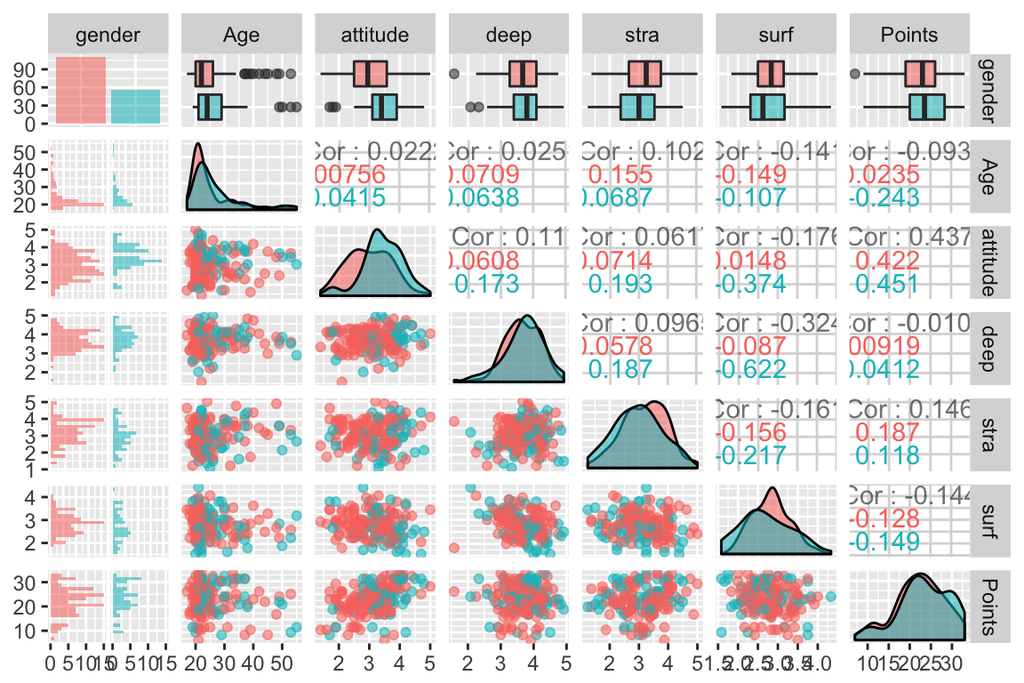

```r
library(GGally) # Loading library for plotting
library(ggplot2) # Loading library for plotting
library(dplyr)
library(MASS) # For LDA
p <- ggpairs(lrn14, mapping = aes(col = gender, alpha = 0.3), lower = list(combo = wrap("facethist", bins = 20)))
p
```

- While performing logistic regression, it is important to test for collinearity of variables as they can lead to overfitting. In order to avoid that, we will test the correlations between the variables. There seems to be a correlation between the Points variable and attitude. Since Points will eventually provide for a dependent variable/target variable, this shouldn’t affect the results. Similarly, we see a negative correlation between all the various categories and surface questions. Also based on the boxplots above, it seems that men have a higher attitude towards statistics as compared to females.

> Description of methods

I will be performing logistic regression and LDA on this dataset. For this reason, I will consider an arbitary score of Points >=18 as Pass and <18 as fail. I will try to come up with a model to explain the features associated with passing and failing of students. Furthermore, I will perform LDA. For LDA we need classes and for this we consider Points >=25 as good students, 21>Points>=25 as intermediate students and Points < 21 as average students

## Logistic Regression

> Creating variables for Log regression

```r
lrn14$Pass <- ifelse(lrn14$Points>=18,1,0)
table(lrn14$Pass)
```

```
##
##   0   1
##  26 140
```

As can be seen from the above table, based on our random cutoff, we have 140 students who have passed the exam and 26 that have failed. Let’s see if the variables explain this classification and if we can correctly predict the individuals who will fail.

```r
model_log_reg <- glm(Pass~Age + attitude + deep + stra + surf, data = lrn14, family = "binomial")
summary(model_log_reg)
```

```
##
## Call:
## glm(formula = Pass ~ Age + attitude + deep + stra + surf, family = "binomial",
##     data = lrn14)
##
## Deviance Residuals:
##     Min       1Q   Median       3Q      Max
## -2.7028   0.3255   0.4561   0.6122   1.1489
##
## Coefficients:
##             Estimate Std. Error z value Pr(>|z|)
## (Intercept)  0.16508    2.80313   0.059  0.95304
## Age         -0.05377    0.02544  -2.113  0.03459 *
## attitude     0.93593    0.32973   2.838  0.00453 **
## deep         0.18428    0.41543   0.444  0.65733
## stra         0.04449    0.30633   0.145  0.88454
## surf        -0.23255    0.46523  -0.500  0.61717
## ---
## Signif. codes:  0 '***' 0.001 '**' 0.01 '*' 0.05 '.' 0.1 ' ' 1
##
## (Dispersion parameter for binomial family taken to be 1)
##
##     Null deviance: 144.10  on 165  degrees of freedom
## Residual deviance: 130.82  on 160  degrees of freedom
## AIC: 142.82
##
## Number of Fisher Scoring iterations: 5
```

```r
OR <- exp(coef(model_log_reg))
CI <- exp(confint(model_log_reg))
cbind(OR, CI)
```

```
##                   OR       2.5 %      97.5 %
## (Intercept) 1.179486 0.004713064 309.4986388
## Age         0.947654 0.901489604   0.9977042
## attitude    2.549582 1.362100144   5.0088068
## deep        1.202355 0.521520031   2.7089530
## stra        1.045490 0.569359683   1.9114181
## surf        0.792510 0.314433980   1.9786411
```

So now we do have the results for the logistic regression from glm. Only attitude and Age seem to be significantly associated with the Pass/Fail status. As can be seen from the odds ratios, for every 1 point increase in attitude, there’s a 2.55 likelihood that the student may pass. Inversely, for every year increase in age, there is 0.95 chance the student may fail.

> Testing the predictive power of the model

```r
probabilities <- predict(model_log_reg, type = "response")
lrn14 <- mutate(lrn14, probability = probabilities)
lrn14 <- mutate(lrn14, prediction = probability > 0.5)
table(Results = lrn14$Pass, prediction = lrn14$prediction) %>% prop.table()
```

```
##        prediction
## Results       FALSE        TRUE
##       0 0.006024096 0.150602410
##       1 0.000000000 0.843373494
```

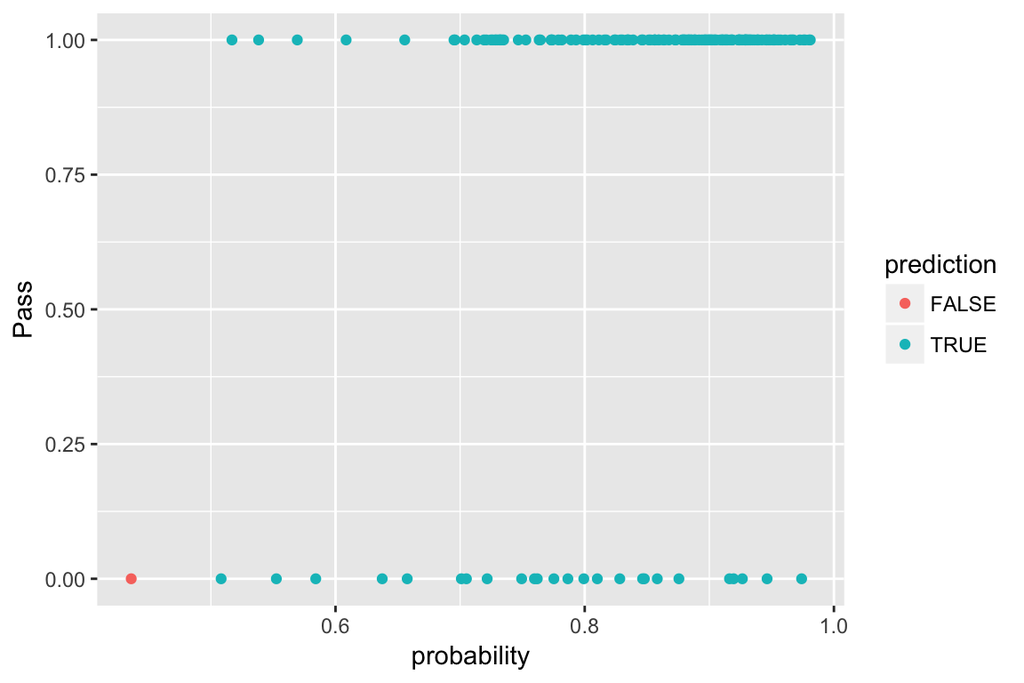

```r
g <- ggplot(lrn14, aes(x = probability, y = Pass, col = prediction))
g + geom_point()
```

As can be seen from the plot and the table, this model is heavily biased trying to pass all the students. Only one student who failed was correctly identified by the model. The accuracy is ~85% however with a very high false positive rate.

## Linear Discriminant Analysis (LDA)

> Creating variables for LDA

```r
bins <- quantile(lrn14$Points, c(0,0.33,0.67,1))
performance <- cut(lrn14$Points, breaks = bins, include.lowest = TRUE, labels = c("poor", "intermediate", "good"))
table(performance)
```

```
## performance
##         poor intermediate         good
##           68           45           53
```

```r
#lrn14 <- select(lrn14, -c(Points, probability, prediction, Pass))
lrn14 <- data.frame(lrn14,performance)
```

Hence we have created a categorical variable for student performance. We have 68 average students, 45 intermediate students and 53 good students.

> Dividing the dataset into train and test

```r
n <- nrow(lrn14)
ind <- sample(n,  size = n * 0.8)
train <- lrn14[ind,]
test <- lrn14[-ind,]
correct_classes <- test$performance
test$performance <- NULL
```

We use 80% of the data as the training dataset.

> Fitting LDA

```r
lda.fit <- lda(performance ~ ., data = train)
lda.fit
```

```
## Call:
## lda(performance ~ ., data = train)
##
## Prior probabilities of groups:
##         poor intermediate         good
##    0.3712121    0.3181818    0.3106061
##
## Group means:
##                genderM      Age attitude     deep     stra     surf
## poor         0.2653061 25.77551 2.773469 3.750000 2.959184 2.824830
## intermediate 0.3333333 26.38095 3.128571 3.646825 3.166667 2.865079
## good         0.3902439 24.60976 3.565854 3.575203 3.314024 2.630081
##                Points      Pass probability predictionTRUE
## poor         16.87755 0.5918367   0.8010233      0.9795918
## intermediate 23.52381 1.0000000   0.8358957      1.0000000
## good         29.31707 1.0000000   0.9004817      1.0000000
##
## Coefficients of linear discriminants:
##                        LD1          LD2
## genderM         0.22763873  0.009160145
## Age            -0.03956162  0.011259722
## attitude        0.45615022 -0.961263965
## deep           -0.32747465 -0.048347312
## stra            0.14498588 -0.287529661
## surf           -0.33617025 -0.606307274
## Points          0.53417586  0.123348413
## Pass           -2.52017443 -3.928570718
## probability    -4.01969892  8.367283435
## predictionTRUE -1.14326608 -1.503880808
##
## Proportion of trace:
##    LD1    LD2
## 0.9682 0.0318
```

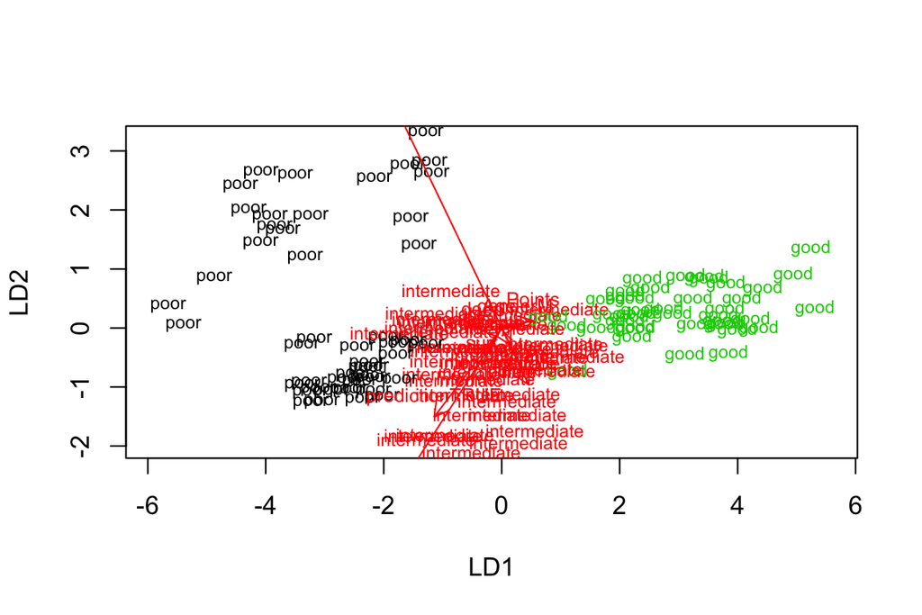

```r
lda.arrows <- function(x, myscale = 1, arrow_heads = 0.1, color = "red", tex = 0.75, choices = c(1,2)){
  heads <- coef(x)
  arrows(x0 = 0, y0 = 0,
         x1 = myscale * heads[,choices[1]],
         y1 = myscale * heads[,choices[2]], col=color, length = arrow_heads)
  text(myscale * heads[,choices], labels = row.names(heads),
       cex = tex, col=color, pos=3)
}
classes <- as.numeric(train$performance)
plot(lda.fit, dimen = 2, col = classes, pch = classes)
lda.arrows(lda.fit, myscale = 1)
```

Performing LDA on the training dataset. Seems like the model fits the data very well based upon the plot.

> Predictive power of the LDA

```r
lda.pred <- predict(lda.fit, newdata = test)
table(correct = correct_classes, predicted = lda.pred$class)
```

```
##               predicted
## correct        poor intermediate good
##   poor           16            3    0
##   intermediate    0            3    0
##   good            0            3    9
```

LDA predicts most individuals correctly.